# E.Sun Data

## Datasets

- ETAB
- Call Center Inbound

## ETAB

## ETAB

- Currently is counted by ticket number (not exactly the amount of people)
- 4274505 tkts in total
- 1655 clerks among 136 branches
- The columns in ETAB (cleaned):

```
##  [1] "brh"        "sale.no"    "tkt.no"     "counter"    "clerk.card"
##  [6] "sta.tm"     "end.tm"     "serv.sec"   "tm.blk"     "wait.sec"
## [11] "wait.num"   "cu.grp"     "proc.dt"    "in.dtm"     "in.dt"
```

- "VIPNO" & "ikey" ignored

## Total Tickets by Date

- Hoildays instered
- Anomaly CW11 (2015-03-09)

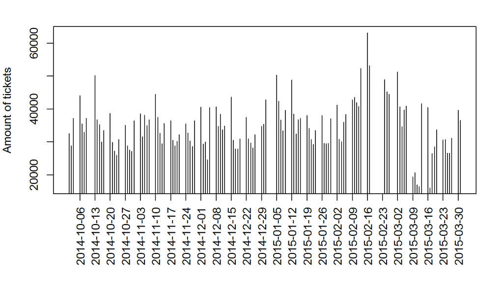

## Calls by Date

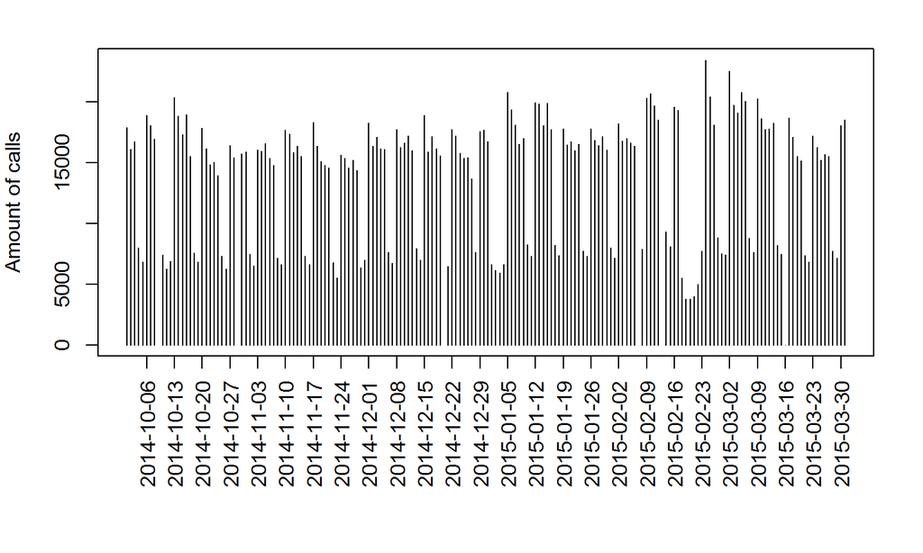

## Customer Types

- Tkts of each customer groups:

```
##
##    GRP1    GRP2    GRP3    GRP4    GRP5
## 3645115  358790  126480    8905  135215
```

- Tkts of each catogories:

```
##
##       A       B       C
## 3789235  358790  126480
```

- A = 一般收付 + VVIP + VIP;  
  1~700 (GRP1) + 901~950 (GRP4) + 951~999 (GRP5)
- B = 外匯服務：701~800 (GRP2);
- C = 服務中心：801~900 (GRP3)

## Total Tickets by Date

- GRP1~5 included

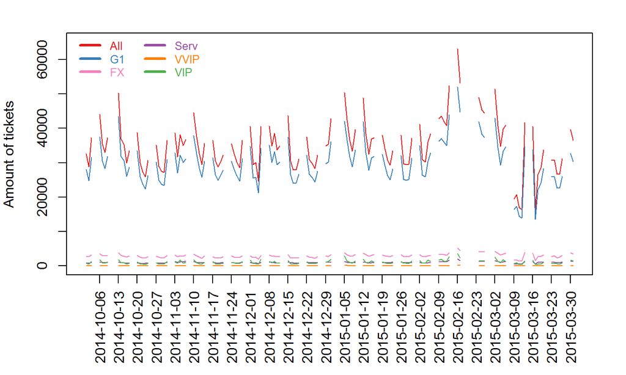

## Total Tickets by Date (GRP2~5)

- Zoom into GRP2~5

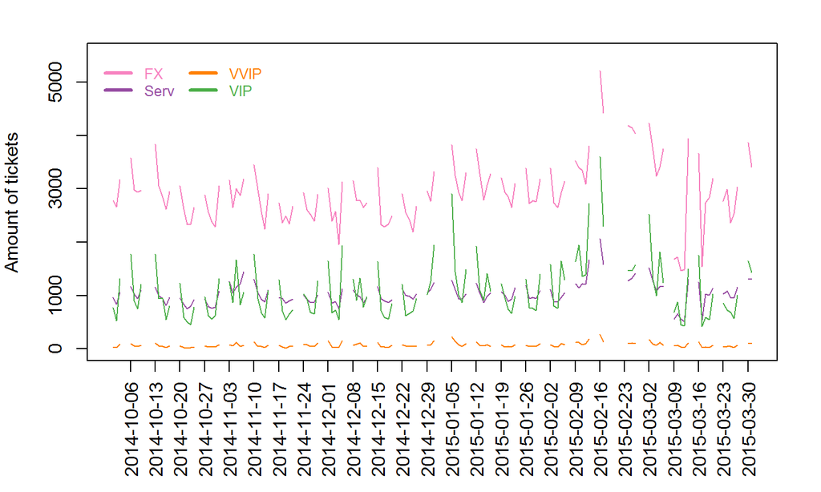

## Ticket No. in Total

- The "skipped ticket" is still included

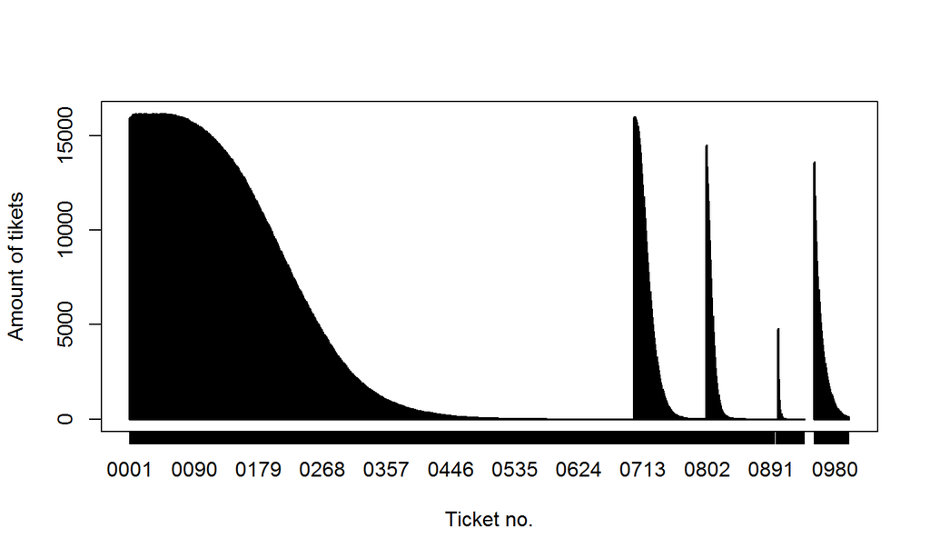

## Ticket No.

- Once reaching the upper limit of ticket no., the counter will return to _01
- None of "0950" & "1000"

```
##          brh tkt.no              in.dtm
## 1504519 0912   0800 2014-11-10 15:32:51
## 2893359 0912   0800 2015-01-05 15:24:31
## 3074470 0912   0800 2015-01-12 14:59:18
## 3499019 0440   0700 2015-02-16 15:17:35
## 3640455 0912   0800 2015-02-13 15:28:29
## 3666732 0912   0800 2015-02-16 14:23:14
## 3687566 0912   0800 2015-02-17 15:34:46
## 3765140 0130   0800 2015-02-16 15:26:56
## 3786539 1067   0900 2015-02-17 15:08:29
## 3857882 0912   0800 2015-03-13 15:29:33
```

## Service Time: Minus Values

- Reason remains unknown

```
##          brh tkt.no serv.sec              in.dtm   sta.tm
## 1654713 0266   0706      -89 2015-02-04 11:36:51 11:36:52
## 1654715 0266   0088     -335 2015-02-04 11:37:35 11:38:42
## 1654718 0266   0090     -511 2015-02-04 11:40:26 11:41:03
## 1977396 0945   0111     -545 2015-03-19 15:48:45 15:48:53
## 2419584 1067   0731      -24 2014-11-27 15:44:44 15:50:59
## 2695458 0048   0010     -447 2015-03-31 09:28:24 09:29:31
## 3650344 1090   0176     -215 2015-01-19 16:07:29 16:10:02
```

## Mean Service Time (by Branch)

```
##       brh     brh.name avg.serv.sec
##   1: 0679     三民分行      5.31634
##   2: 1355     太平分行     19.50899
##   3: 1366     台中分行     20.94512
##   4: 0233     永康分行     21.42515
##   5: 1012     迴龍分行     22.59126
##  ---
## 132: 1344     竹科分行    633.58432
## 133: 0543     五股分行    703.91035
## 134: 0587 新板特區分行    714.11320
## 135: 1377     六家分行    775.28864
## 136: 1182     南港分行    802.06083
```

## Mean Service Time (by Branch)

- Split roughly from 15 sec (will be examined later)
- Then sort by lt15.pct

```
##       brh serv.total  lt15.pct brh.name avg.serv.sec
##   1: 0679      36739 97.452299 三民分行      5.31634
##   2: 1403      15807 95.236288 安南分行     36.70260
##   3: 0233      41315 93.622171 永康分行     21.42515
##   4: 1104      22259 93.261153 員林分行     36.35680
##   5: 1229      11930 91.139983 信義分行     51.82900
##  ---
## 132: 0495      27665  1.698898 光華分行    517.09770
## 133: 0532      43913  1.691982 城中分行    415.58591
## 134: 1034      24624  1.555393 澎湖分行    390.41516
## 135: 0901      28075  1.164737 北新分行    513.66077
## 136: 0211      23409  1.136315 民生分行    595.48392
```

## Mean Service Time (001~700)

- Rank 1 三民分行

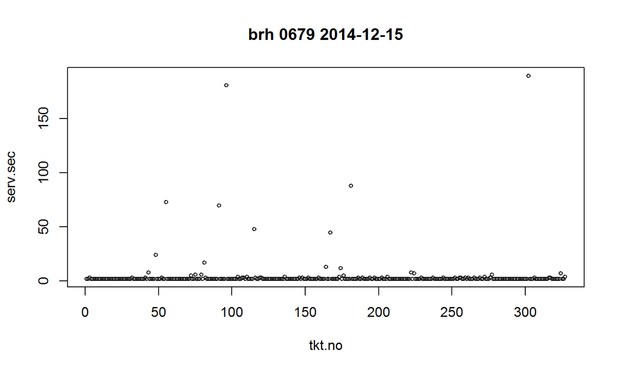

## Mean Service Time (001~700)

- Rank 130 內湖分行

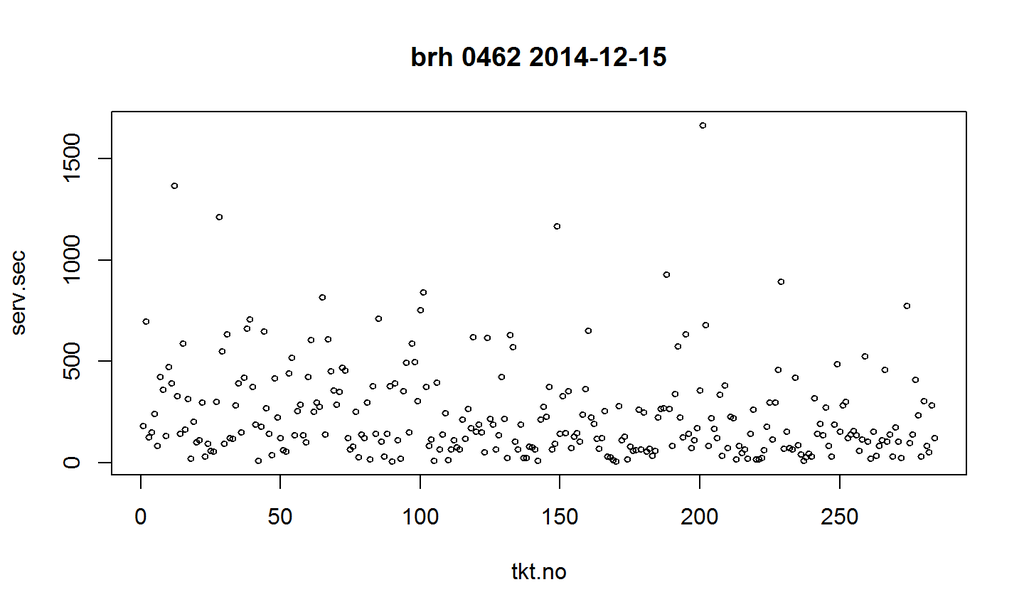

## Least-20 of Service Time

```
##      brh   brh.name rank  brh   brh.name
##  1: 0679   三民分行   11 0990   草屯分行
##  2: 1403   安南分行   12 1366   台中分行
##  3: 0233   永康分行   13 1274   鹽行分行
##  4: 1104   員林分行   14 1012   迴龍分行
##  5: 1229   信義分行   15 1160 南勢角分行
##  6: 1355   太平分行   16 1322   藝文分行
##  7: 1311 南永康分行   17 1045   三峽分行
##  8: 0808   連城分行   18 1230   汐止分行
##  9: 0624   大順分行   19 0381   豐原分行
## 10: 1399   烏日分行   20 0819   林園分行
```

## Service Time Filtering

- First exclude the branches with service time least-20
- Then filter out service time which is less-than-15secs

## Service Time Filtered (GRP1~5)

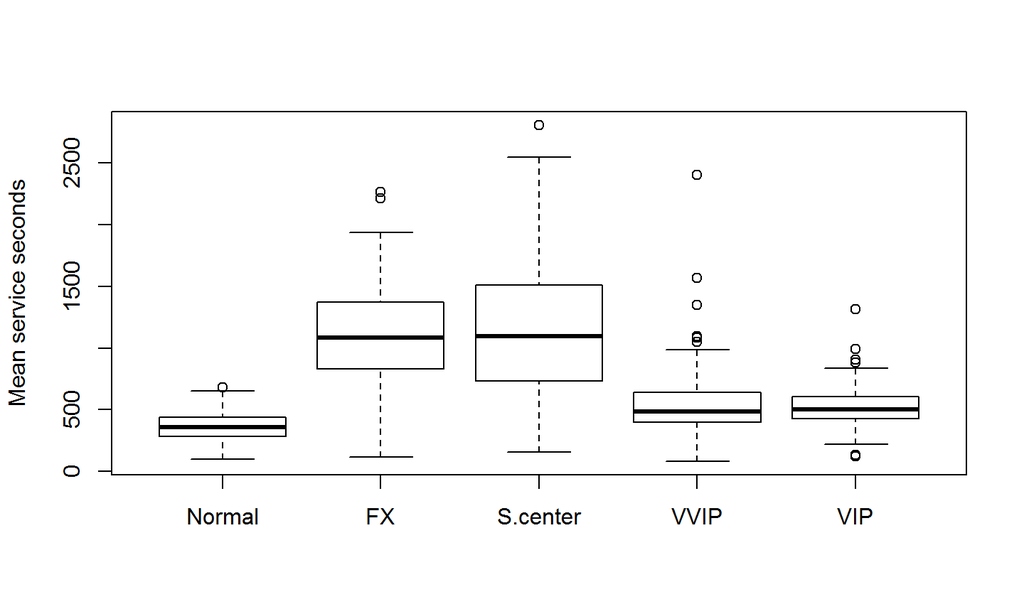

## Waiting Time Filtered (GRP1~5)

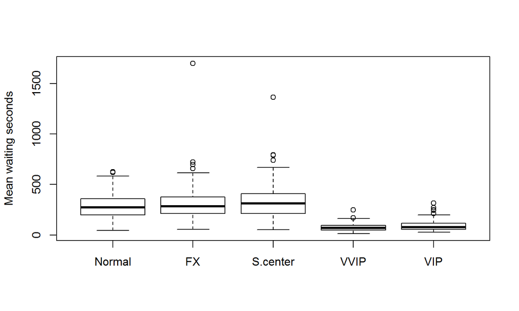

## Info by Branches (.csv)

```
##     brh cu.grp m.clerk.num   m.serv   m.wait m.tkt.num m.wait.num
## 1: 0015   GRP1    5.713115 475.9377 264.4846  80.04098   3.177973
## 2: 0026   GRP1    8.737705 458.6697 204.5174  60.51639   3.581049
## 3: 0048   GRP1    7.438017 459.5040 381.5265  49.54545   5.289249
## 4: 0059   GRP1    6.008197 391.6789 246.8702  55.51639   3.604613
## 5: 0060   GRP1   10.305785 425.1578 331.3580  57.83471   5.402265
## 6: 0071   GRP1    8.122951 277.4093 595.4464  77.84426  10.194269
##    sd.clerk.num  sd.serv  sd.wait sd.tkt.num sd.wait.num
## 1:    1.4909064 91.14901 209.8434  113.79454    2.178903
## 2:    1.4477299 63.52518 146.3265   90.03463    2.297793
## 3:    0.8934256 77.98753 199.3685   84.08280    2.684493
## 4:    1.0640318 65.08017 206.1694   95.41490    2.881295
## 5:    1.5102040 60.17832 239.2980   87.31527    4.045565
## 6:    1.1612039 37.82074 310.0775  110.10356    6.085267
```

## Call Center Inbound

## Operators (.csv)

```
##                          opr.id.md5   m.call  call.sd   start.dt
## 1: A5D0E3784E159C774C356EE1AE2E8EA0 192.4352 35.79857 2014-10-01
## 2: CBCC7F3540C01B2139767ED8B92C15DB 186.6833 34.50417 2014-10-01
## 3: F01BF43F89479D83936C7A82998B817F 179.2411 54.18109 2014-10-02
## 4: 4AFA572EB547A52C1E86BF95C0BD93CA 175.0000       NA 2014-10-05
## 5: CB82E1622243DF312040A5B183866750 174.1983 48.61629 2014-10-01
## 6: 41F116BDE91E3AECBB0C2C9E0740DC1D 170.8739 29.00864 2014-10-01
##       last.dt days l_s
## 1: 2015-03-30  108 181
## 2: 2015-03-31  120 182
## 3: 2015-03-30  112 180
## 4: 2014-10-05    1   1
## 5: 2015-03-31  121 182
## 6: 2015-03-30  119 181
```